# Blood Processing Analysis

```r
library(tidyverse)
library(jsonlite)
library(cowplot)
library(stringr)
library(knitr)
library(mgcv)
library(gratia)
library(glue)

library(kinfitr)
library(bloodstream)

configpath <- params$configpath
configname <- basename(configpath)

config_suffix <- str_match(configname, "^config_?-?(.*)\\.json")[,2]

config <- jsonlite::fromJSON(configpath)
config_subset <- parse_config_subsets(config)

theme_set(theme_light())
```

## Modelling

Here are the contents of the config file with regard to which models will be fit to the data and how.

```r
str(config$Model)
```

```
## List of 4
##  $ ParentFraction:List of 6
##   ..$ Method      : chr "Interpolation"
##   ..$ set_ppf0    : logi TRUE
##   ..$ starttime   : int 0
##   ..$ endtime     : num Inf
##   ..$ gam_k       : chr "6"
##   ..$ hgam_formula: chr ""
##  $ BPR           :List of 5
##   ..$ Method      : chr "Interpolation"
##   ..$ starttime   : int 0
##   ..$ endtime     : num Inf
##   ..$ gam_k       : int 6
##   ..$ hgam_formula: chr ""
##  $ AIF           :List of 8
##   ..$ Method        : chr "Interpolation"
##   ..$ starttime     : int 0
##   ..$ endtime       : num Inf
##   ..$ expdecay_props: logi [1:2] NA NA
##   ..$ inftime       : logi NA
##   ..$ spline_kb     : chr ""
##   ..$ spline_ka_m   : chr ""
##   ..$ spline_ka_a   : chr ""
##  $ WholeBlood    :List of 7
##   ..$ Method     : chr "Interpolation"
##   ..$ dispcor    : logi FALSE
##   ..$ starttime  : int 0
##   ..$ endtime    : num Inf
##   ..$ spline_kb  : chr ""
##   ..$ spline_ka_m: chr ""
##   ..$ spline_ka_a: chr ""
```

## Load the data

```r
bidsdata <- bids_parse_study(params$studypath)

extra_pet_details <- map(bidsdata$petinfo,
                           get_filterable_attributes) %>%
    bind_rows()

bidsdata <- bind_cols(extra_pet_details, bidsdata) %>%
    all_identifiers_to_character()


bidsdata$pet <- attributes_to_title(bidsdata)
bidsdata$fulltitle <- attributes_to_title(bidsdata, all_attributes = T)
```

## Quality Control

#### Parent Fraction

```r
pf_warnings <- map2_chr(bidsdata$blooddata, bidsdata$pet, qc_parentFraction)

pf_warnings <- pf_warnings[!is.na(pf_warnings)]

if(length(pf_warnings) > 0) {
  glue_collapse(pf_warnings)
} else {
  glue_collapse("No detected issues.")
}
```

- **sub-01_ses-baseline** has duplicated parentFraction time points.

#### Blood-to-Plasma Ratio

```r
bpr_warnings <- map2_chr(bidsdata$blooddata, bidsdata$pet, qc_bpr)

bpr_warnings <- bpr_warnings[!is.na(bpr_warnings)]

if(length(bpr_warnings) > 0) {
  glue_collapse(bpr_warnings)
} else {
  glue_collapse("No detected issues.")
}
```

- **sub-02_ses-baseline** has BPR values less than 0: min -2.1.
- **sub-02_ses-blocked** has BPR values less than 0: min -5.58.

#### Whole Blood

```r
wb_warnings <- map2_chr(bidsdata$blooddata, bidsdata$pet, qc_wb)

wb_warnings <- wb_warnings[!is.na(wb_warnings)]

if(length(wb_warnings) > 0) {
  glue_collapse(wb_warnings)
} else {
  glue_collapse("No detected issues.")
}
```

- **sub-01_ses-baseline** has duplicated whole blood time points. This is possible with manual and automatic time points, but this could be caused by manual samples in the auto data.

### Plotting

Below is the raw blood data prior to any modelling. Inspect these plots to to check for strange values. The left plot is with the original times, while the right plot presents a log-scaled x axis, allowing closer inspection of the early parts of the curve.

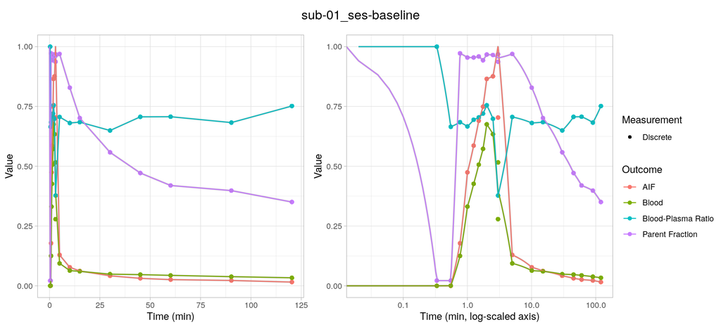

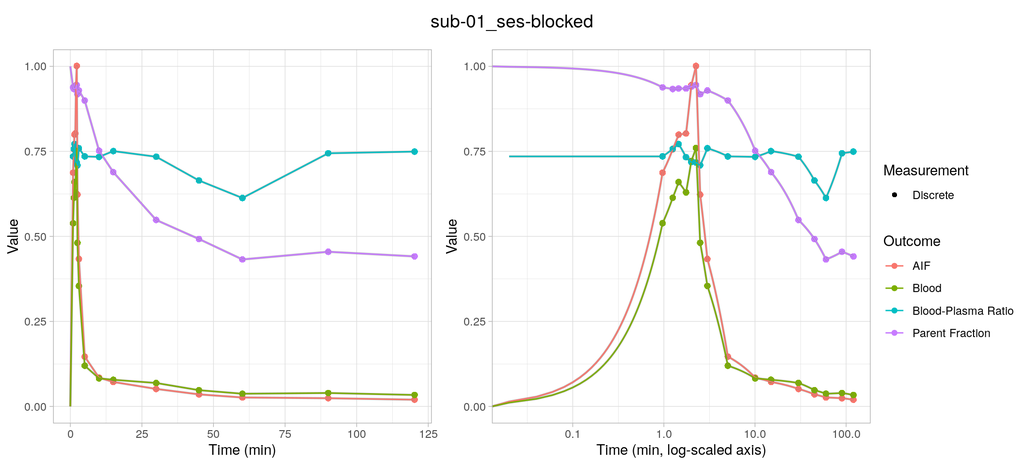

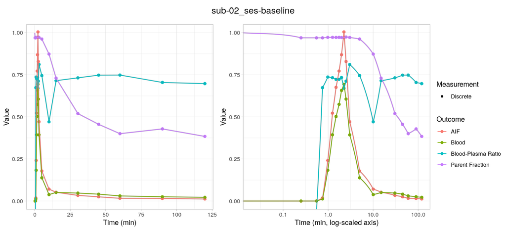

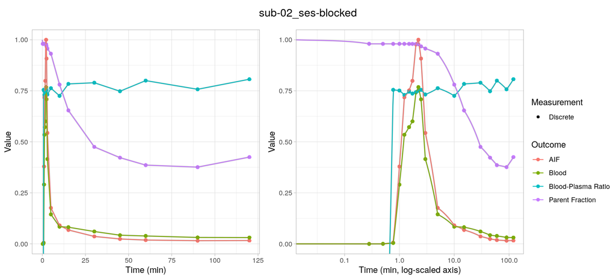

```r
map2(bidsdata$blooddata, bidsdata$pet,
     ~plot_blooddata_extra(.x, .y))
```

## Modelling

### Parent Fraction

The selected modelling approach for modelling the parent fraction (PF) data is Interpolation.

### Blood-to-Plasma Ratio

The selected modelling approach for modelling the blood-to-plasma (BPR) ratio data is Interpolation.

### Arterial Input Function

The selected modelling approach for modelling the arterial input function (AIF) data is Interpolation.

### Whole Blood

The selected modelling approach for modelling the whole blood (WB) data is Interpolation.

## Final Plotting

Because no modelling was performed, the final plots are the same as the initial plots.

## Output

First, we create the relevant filenames, and delete any files in the relevant folders.

```r
bidsdata <- bidsdata %>%
  mutate(bloodfilename = map_chr(filedata, ~.x %>%
                                  filter(measurement == "blood") %>%
                                  filter(str_detect(path, "manual_blood.json")) %>%
                                  slice(1) %>%
                                  pull(path) )) %>%
  # Blood tsv file
  mutate(output_basename = basename(bloodfilename),
         output_basename = str_replace(output_basename,
                                       "_recording-manual_blood.json",
                                       "_inputfunction.tsv"),
         output_folder = dirname(bloodfilename),
         output_filename = paste0(params$studypath, "/derivatives/bloodstream",
                                  config_suffix, "/",
                                  output_folder, "/", output_basename)) %>%
  # Blood json file
  mutate(output_json_filename = str_replace(output_filename, "_inputfunction.tsv",
                                           "_inputfunction.json")) %>%
  # Blood config file
  mutate(output_cfg_filename = str_replace(output_filename, "_inputfunction.tsv",
                                           "_config.json"))

file.remove(bidsdata$output_filename)
file.remove(bidsdata$output_json_filename)
file.remove(bidsdata$output_cfg_filename)
```

Now the final curves need to be interpolated…

```r
bidsdata <- bidsdata %>%
  mutate(input = map(blooddata, bd_create_input)) %>%
  mutate(input = map(input, ~rename(.x,
                          "time" = Time,
                          "whole_blood_radioactivity" = Blood,
                          "plasma_radioactivity" = Plasma,
                          "metabolite_parent_fraction" = ParentFraction,
                          AIF = AIF))) %>%
  #unit_conversion
  mutate(input = map(input, ~mutate(.x,
         # min to sec
         time = time * 60,
         # kBq to Bq
         whole_blood_radioactivity = unit_convert(whole_blood_radioactivity,
                                                  from_units = "kBq",
                                                  to_units = "Bq"),
         plasma_radioactivity = unit_convert(plasma_radioactivity, "kBq", "Bq"),
         AIF = unit_convert(AIF, "kBq", "Bq"))))
```

… and save the tabular tsv files to the derivatives folder.

```r
walk( dirname(bidsdata$output_filename),
      dir.create, recursive=T)

# Save interpolated tsv files
walk2(bidsdata$input,
     bidsdata$output_filename, ~write_delim(.x, file=.y,
                                            delim = "\t"))
```

We also save json sidecars to accompany all the tabular data.

```r
output_description <- list(
  time = list(
      Description = "Interpolated time in relation to time zero defined in _pet.json",
      Units = "s"
    ),
    whole_blood_radioactivity = list(
      Description = "Estimated interpolated radioactivity in whole blood samples",
      Units = "Bq"
    ),
    plasma_radioactivity = list(
      Description = "Estimated interpolated radioactivity in whole plasma samples",
      Units = "Bq"
    ),
    AIF = list(
      Description = "Estimated interpolated radioactivity in metabolite-corrected arterial plasma samples",
      Units = "Bq"
    )
)

# Save interpolated json sidecars
walk(bidsdata$output_json_filename, ~write_json(output_description, path = .x,
                                                pretty=TRUE))
```

And finally, we save a dataset description file

```r
dataset_description <- list(
  Name = "bloodstream Outputs",
  BIDSVersion = "1.7.0",
  DatasetType = "derivative",
  GeneratedBy = list(
    Name = "bloodstream",
    Version = as.character(packageVersion("bloodstream")),
    Container = NULL
  )
)

jsonlite::write_json(dataset_description,
                     path = paste0(params$studypath,
                                   "/derivatives/bloodstream", config_suffix,
                                   "/dataset_description.json"),
                     pretty = T)
```